## Citation

Mangiola et al., (2020). tidyHeatmap: an R package for modular heatmap production based on tidy principles. Journal of Open Source Software, 5(52), 2472, https://doi.org/10.21105/joss.02472

Please have a look also to

website: [stemangiola.github.io/tidyHeatmap](https://stemangiola.github.io/tidyHeatmap/)

`tidyHeatmap` is a package that introduces tidy principles to the creation of information-rich heatmaps. This package uses [ComplexHeatmap](https://bioconductor.org/packages/release/bioc/html/ComplexHeatmap.html) as graphical engine.

**Advantages:**

- Modular annotation with just specifying column names
- Custom grouping of rows is easy to specify providing a grouped tbl. For example `df |> group_by(...)`
- Labels size adjusted by row and column total number
- Default use of Brewer and Viridis palettes

## Functions/utilities available

| Function | Description |
| --- | --- |
| `heatmap` | Plots base heatmap |
| `add_tile` | Adds tile annotation to the heatmap |
| `add_point` | Adds point annotation to the heatmap |
| `add_bar` | Adds bar annotation to the heatmap |
| `add_line` | Adds line annotation to the heatmap |
| `layer_point` | Adds layer of symbols on top of the heatmap |
| `layer_square` | Adds layer of symbols on top of the heatmap |
| `layer_diamond` | Adds layer of symbols on top of the heatmap |
| `layer_arrow_up` | Adds layer of symbols on top of the heatmap |
| `layer_arrow_down` | Add layer of symbols on top of the heatmap |
| `split_rows` | Splits the rows based on the dendogram |
| `split_columns` | Splits the columns based on the dendogram |
| `save_pdf` | Saves the PDF of the heatmap |

## Installation

To install the most up-to-date version

```r
devtools::install_github("stemangiola/tidyHeatmap")
```

To install the most stable version (however please keep in mind that this package is under a maturing lifecycle stage)

```r
install.packages("tidyHeatmap")
```

## Contribution

If you want to contribute to the software, report issues or problems with the software or seek support please open an issue [here](https://github.com/stemangiola/tidyHeatmap/issues)

## Input data frame

The heatmaps visualise a multi-element, multi-feature dataset, annotated with independent variables. Each observation is a element-feature pair (e.g., person-physical characteristics).

| element | feature | value | independent_variables |
| --- | --- | --- | --- |
| `chr` or `fctr` | `chr` or `fctr` | `numeric` | … |

Let’s transform the mtcars dataset into a tidy “element-feature-independent variables” data frame. Where the independent variables in this case are ‘hp’ and ‘vs’.

```r
mtcars_tidy <-
    mtcars |>
    as_tibble(rownames="Car name") |>

    # Scale
    mutate_at(vars(-`Car name`, -hp, -vs), scale) |>

    # tidyfy
    pivot_longer(cols = -c(`Car name`, hp, vs), names_to = "Property", values_to = "Value")

mtcars_tidy
```

```
## # A tibble: 288 x 5
##    `Car name`       hp    vs Property Value[,1]
##    <chr>         <dbl> <dbl> <chr>        <dbl>
##  1 Mazda RX4       110     0 mpg          0.151
##  2 Mazda RX4       110     0 cyl         -0.105
##  3 Mazda RX4       110     0 disp        -0.571
##  4 Mazda RX4       110     0 drat         0.568
##  5 Mazda RX4       110     0 wt          -0.610
##  6 Mazda RX4       110     0 qsec        -0.777
##  7 Mazda RX4       110     0 am           1.19
##  8 Mazda RX4       110     0 gear         0.424
##  9 Mazda RX4       110     0 carb         0.735
## 10 Mazda RX4 Wag   110     0 mpg          0.151
## # … with 278 more rows
```

## Plotting

For plotting, you simply pipe the input data frame into heatmap, specifying:

- The rows, cols relative column names (mandatory)
- The value column name (mandatory)
- The annotations column name(s)

mtcars

```r
mtcars_heatmap <-
    mtcars_tidy |>
    heatmap(`Car name`, Property, Value ) |>
    add_tile(hp)
```

```
## tidyHeatmap says: (once per session) from release 1.2.3 the grouping labels have white background by default. To add color for one-ay grouping specify palette_grouping = list(c("red", "blue"))
```

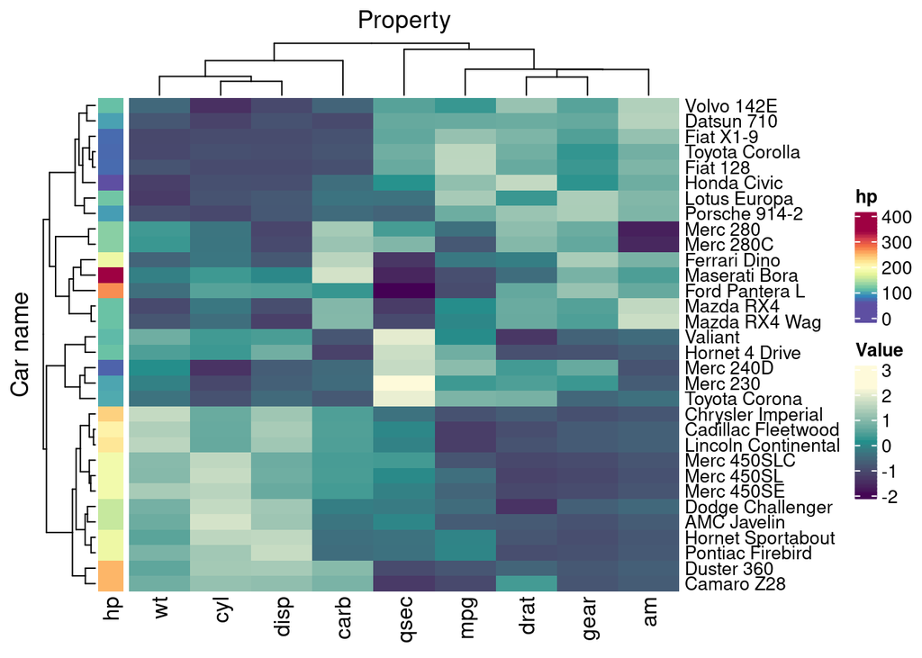

```r
mtcars_heatmap
```

## Saving

```r
mtcars_heatmap |> save_pdf("mtcars_heatmap.pdf")
```

## Grouping and splitting

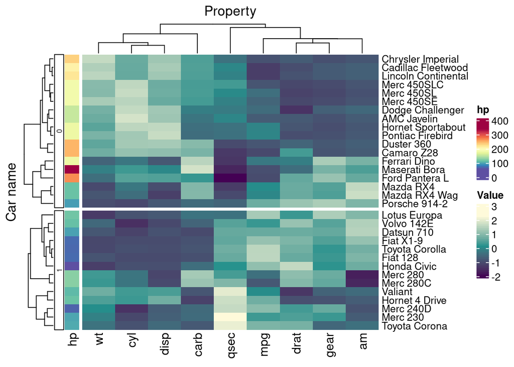

```r
mtcars_tidy |>
    group_by(vs) |>
    heatmap(`Car name`, Property, Value ) |>
    add_tile(hp)
```

We can provide colour palettes to groupings

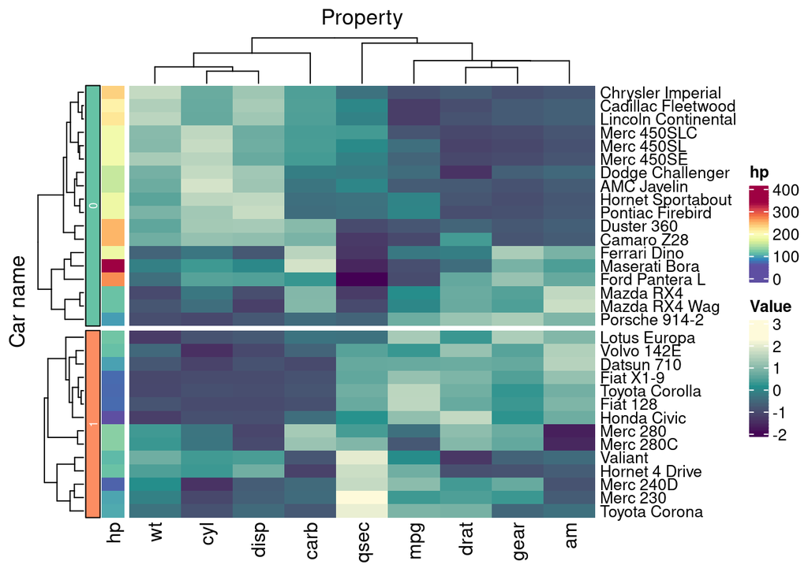

```r
mtcars_tidy |>
    group_by(vs) |>
    heatmap(
        `Car name`, Property, Value ,
        palette_grouping = list(c("#66C2A5", "#FC8D62"))
    ) |>
    add_tile(hp)
```

We can split based on the cladogram

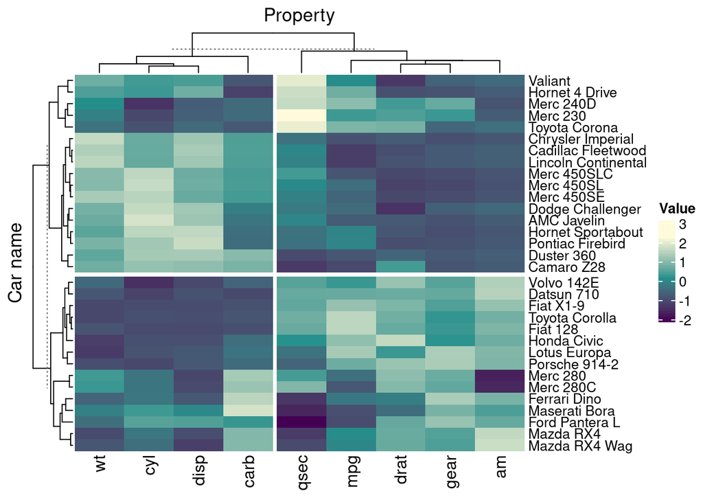

```r
mtcars_tidy |>
    heatmap(`Car name`, Property, Value ) |>
    split_rows(2) |>
    split_columns(2)
```

We can Split on kmean clustering (using ComplexHeatmap options, it is stokastic)

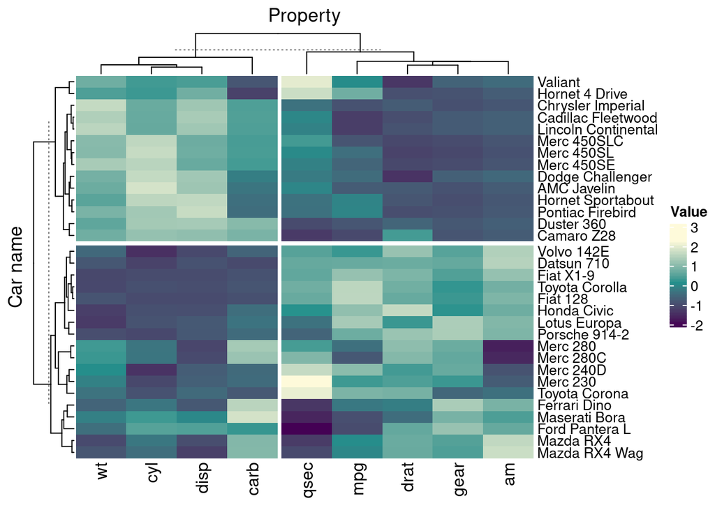

```r
mtcars_tidy |>
    heatmap(
        `Car name`, Property, Value ,
        row_km = 2,
        column_km = 2
    )
```

## Custom palettes

We can easily use custom palette, using strings, hexadecimal color character vector,

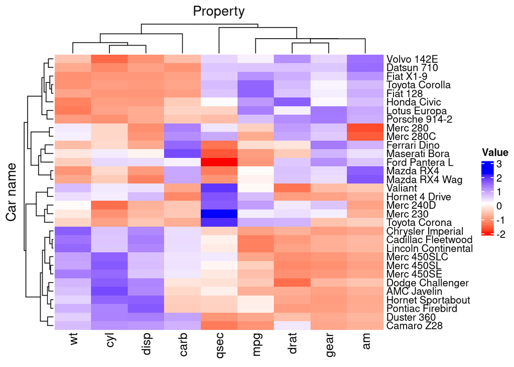

```r
mtcars_tidy |>
    heatmap(
        `Car name`,
        Property,
        Value,
        palette_value = c("red", "white", "blue")
    )
```

A better-looking blue-to-red palette

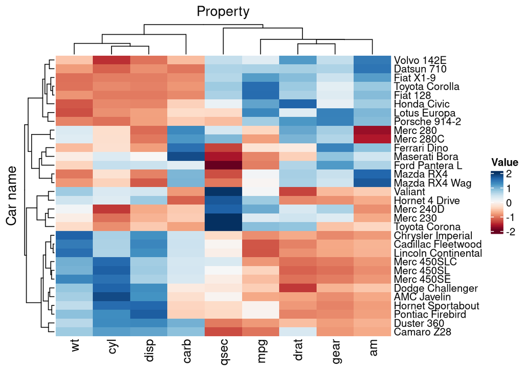

```r
mtcars_tidy |>
    heatmap(
        `Car name`,
        Property,
        Value,
        palette_value = circlize::colorRamp2(
            seq(-2, 2, length.out = 11),
            RColorBrewer::brewer.pal(11, "RdBu")
        )
    )
```

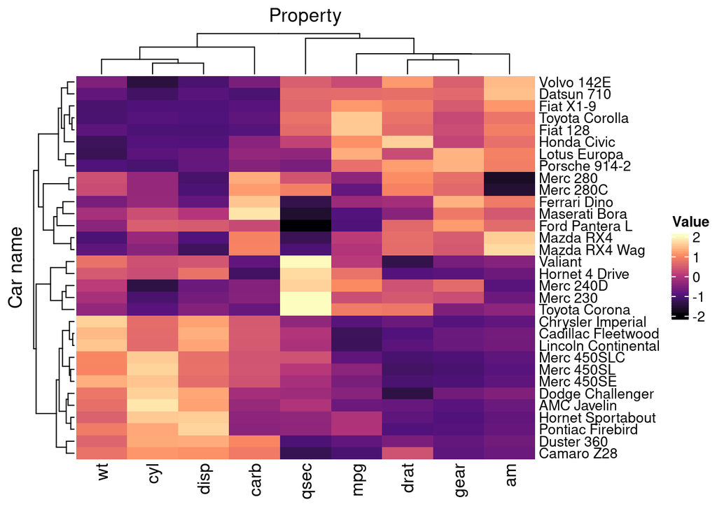

```r
mtcars_tidy |>
    heatmap(
        `Car name`,
        Property,
        Value,
        palette_value = circlize::colorRamp2(c(-2, -1, 0, 1, 2), viridis::magma(5))
    )
```

## Multiple groupings and annotations

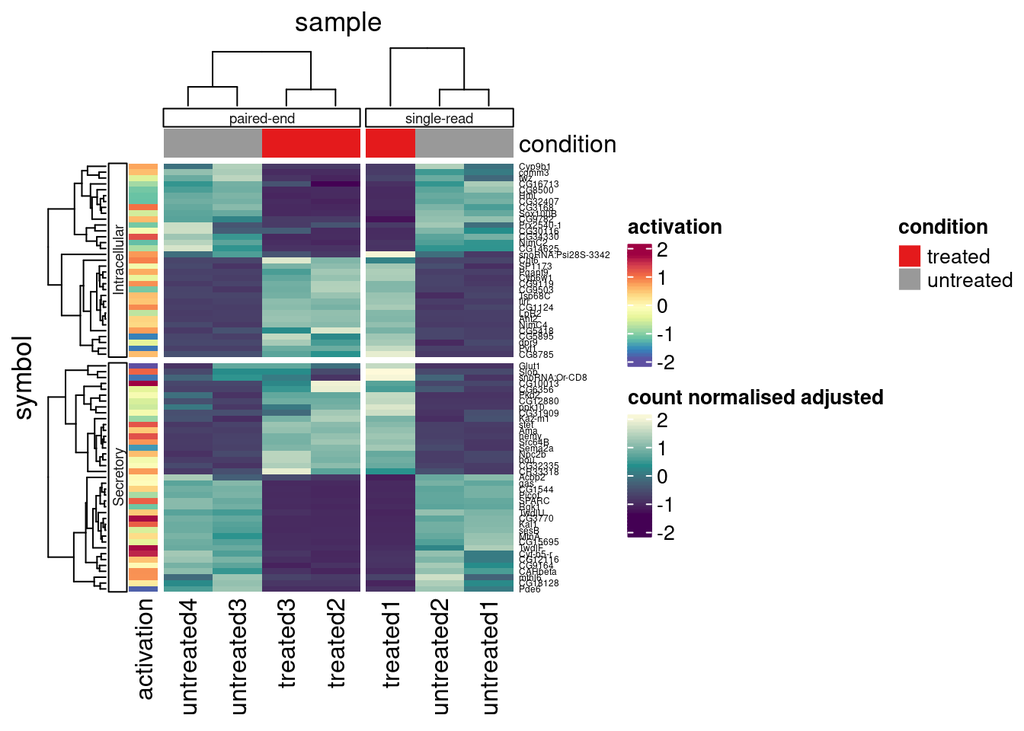

```r
tidyHeatmap::pasilla |>
    group_by(location, type) |>
    heatmap(
        .column = sample,
        .row = symbol,
        .value = `count normalised adjusted`
    ) |>
    add_tile(condition) |>
    add_tile(activation)
```

Remove legends, adding aesthetics to annotations in a modular fashion, using `ComplexHeatmap` arguments

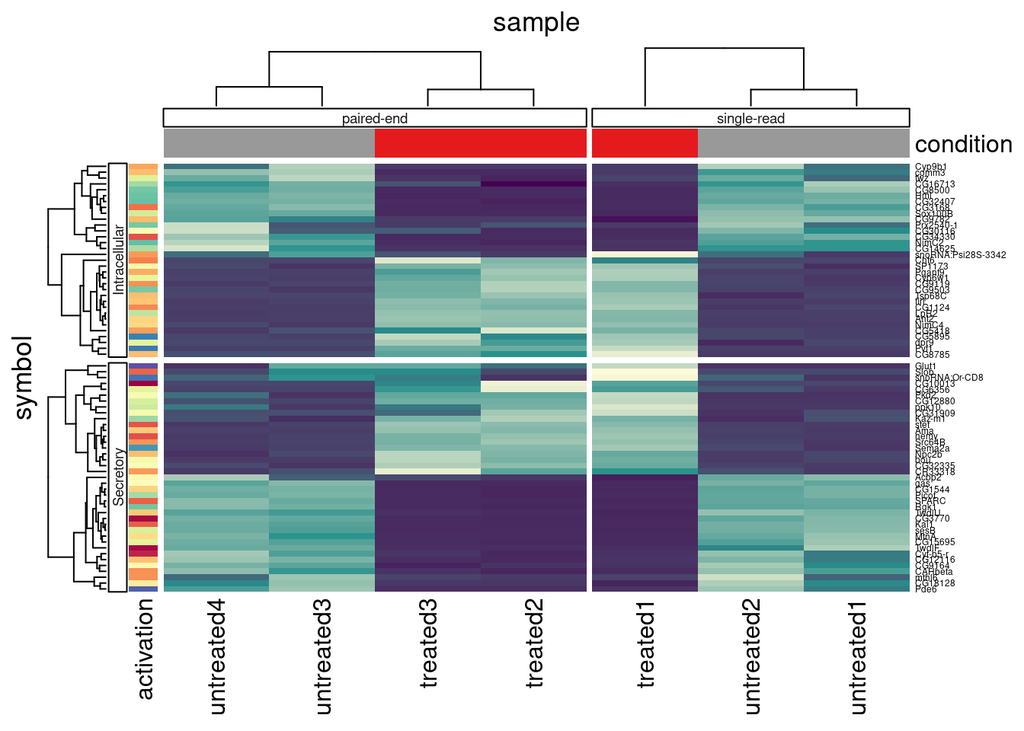

```r
tidyHeatmap::pasilla |>
    group_by(location, type) |>
    heatmap(
        .column = sample,
        .row = symbol,
        .value = `count normalised adjusted`,
        show_heatmap_legend = FALSE
    ) |>
    add_tile(condition, show_legend = FALSE) |>
    add_tile(activation, show_legend = FALSE)
```

## Annotation types

“tile”, “point”, “bar” and “line” are available

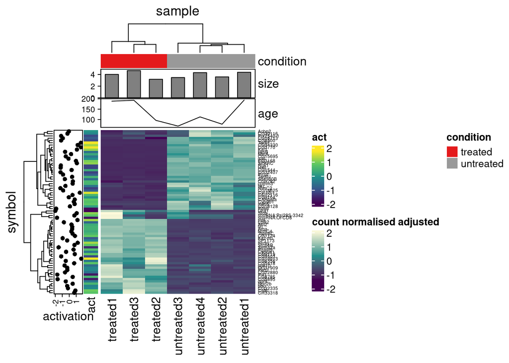

```r
# Create some more data points
pasilla_plus <-
    tidyHeatmap::pasilla |>
    dplyr::mutate(act = activation) |>
    tidyr::nest(data = -sample) |>
    dplyr::mutate(size = rnorm(n(), 4,0.5)) |>
    dplyr::mutate(age = runif(n(), 50, 200)) |>
    tidyr::unnest(data)

# Plot
pasilla_plus |>
    heatmap(
        .column = sample,
        .row = symbol,
        .value = `count normalised adjusted`
    ) |>
    add_tile(condition) |>
    add_point(activation) |>
    add_tile(act) |>
    add_bar(size) |>
    add_line(age)
```

## Annotation size

We can customise annotation sizes, using the `grid::unit()`

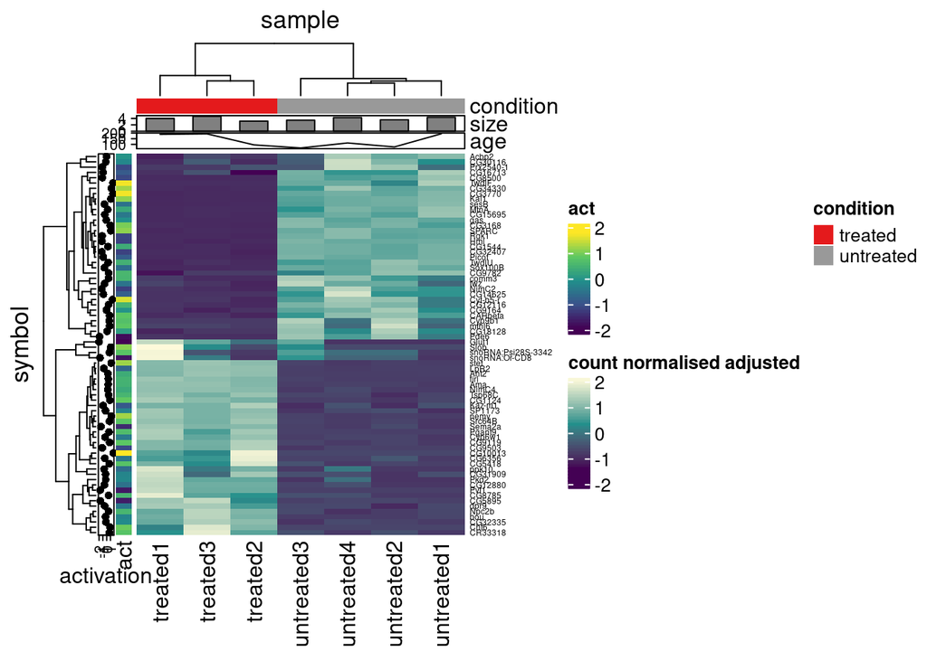

```r
pasilla_plus |>
    heatmap(
        .column = sample,
        .row = symbol,
        .value = `count normalised adjusted`
    ) |>
    add_tile(condition, size = unit(0.3, "cm")) |>
    add_point(activation, size = unit(0.3, "cm")) |>
    add_tile(act, size = unit(0.3, "cm")) |>
    add_bar(size, size = unit(0.3, "cm")) |>
    add_line(age, size = unit(0.3, "cm"))
```

# Layer symbol

Add a layer on top of the heatmap

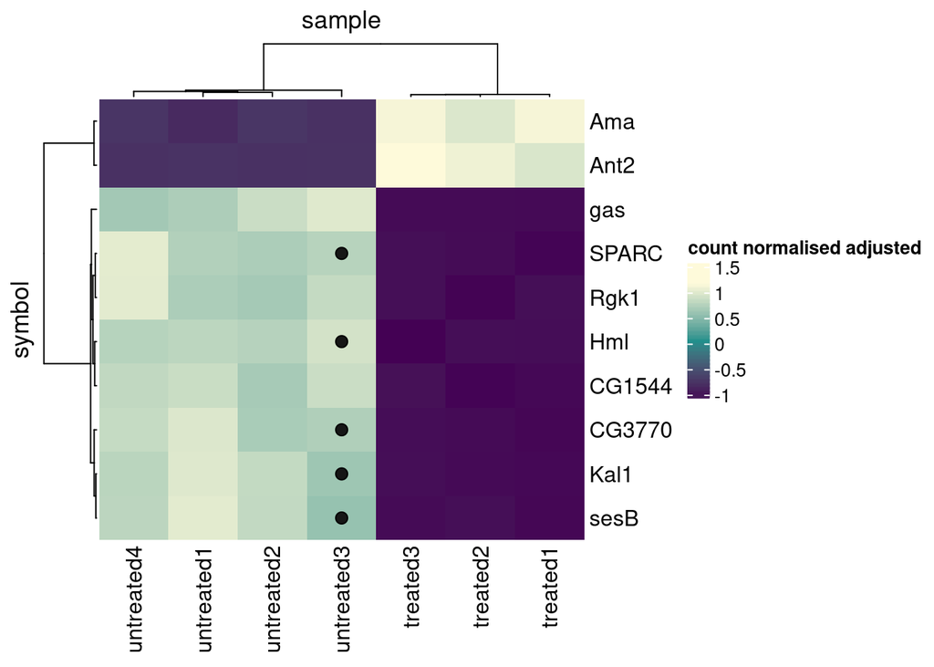

```r
tidyHeatmap::pasilla |>

    # filter
    filter(symbol %in% head(unique(tidyHeatmap::pasilla$symbol), n = 10)) |>

    heatmap(
        .column = sample,
        .row = symbol,
        .value = `count normalised adjusted`
    ) |>
    layer_point(
        `count normalised adjusted log` > 6 & sample == "untreated3"
    )
```

# ComplexHeatmap further styling

Add cell borders

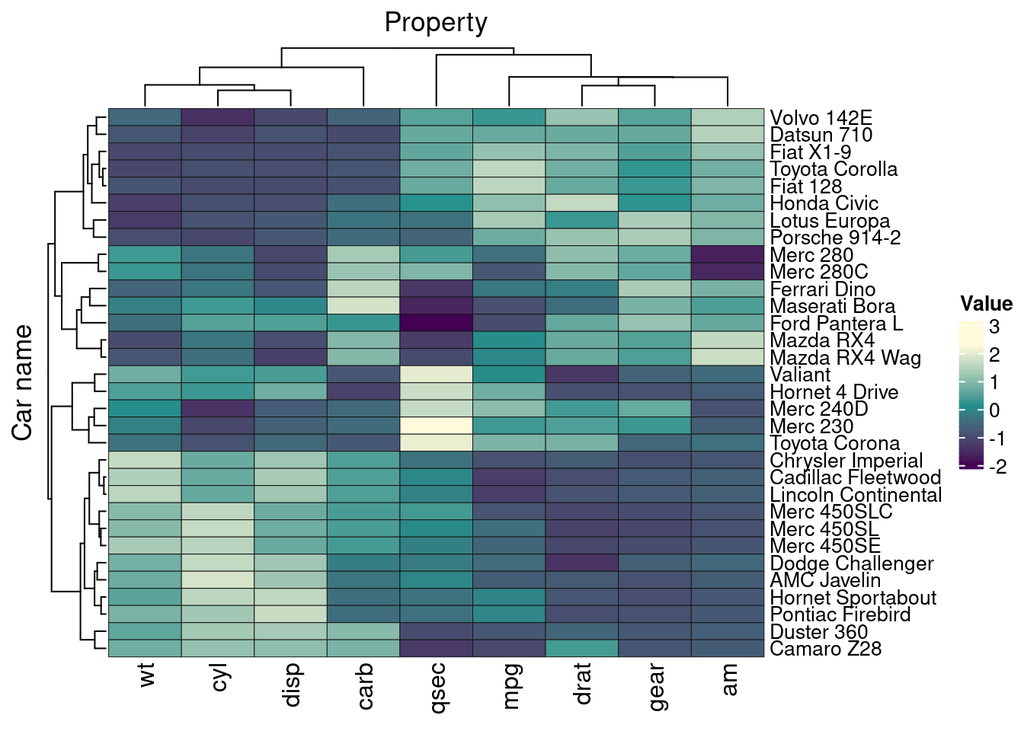

```r
mtcars_tidy |>
    heatmap(
        `Car name`, Property, Value,
        rect_gp = grid::gpar(col = "#161616", lwd = 0.5)
    )
```

Drop row clustering

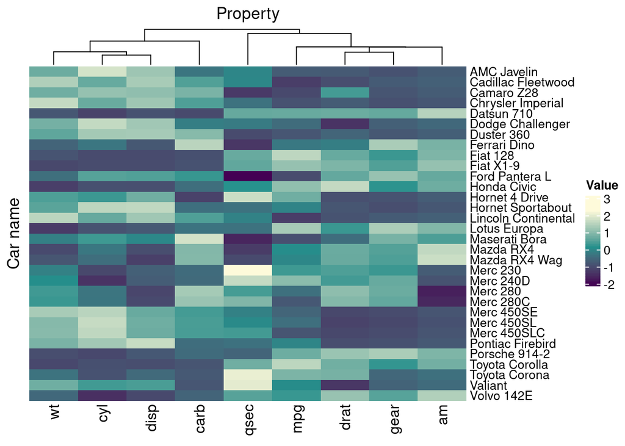

```r
mtcars_tidy |>
    heatmap(
        `Car name`, Property, Value,
        cluster_rows = FALSE
    )
```

Reorder rows elements

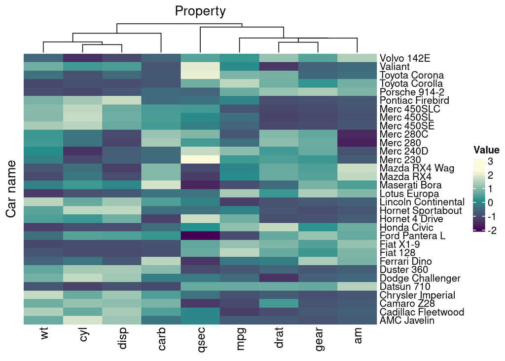

```r
library(forcats)
mtcars_tidy |>
    mutate(`Car name` = fct_reorder(`Car name`, `Car name`, .desc = TRUE)) %>%
    heatmap(
        `Car name`, Property, Value,
        cluster_rows = FALSE
    )
```